# Assignment11

Anna Lisa and Wenjia

2023-07-05

##Task 1: MSMB 05

Clustering is a useful technique for understanding complex multivariate data; it is unsupervised machine learning –> Clustering is more general than EM-algorithm, and can be applied to more complex data

What is similar ? Different approaches: Euclidean distance (d(A,B)=Wurzel((a1-b1)^2 + ….)), Manhattan Block ( distance takes the sum of the absolute differences in all coordinates), Maximum, weighted Euklidean distance, Binary und viele viele mehr

## k-means method:

1. Starts from a matrix of features measured on a set of observations.
2. Randomly pick distinct cluster centers out of the observations (“seeds”).
3. Assign each of the remaining observation to the group to whose center it is the closest.
4. For each group, choose a new center from the observations in the group, such that the sum of the distances of group members to the center is minimal; this is called the medoid.
5. Repeat Steps 3 and 4 until the groups stabilize.

## Density-based clustering

This method looks for regions of high density separated by sparser regions. It has the advantage of being able to cope with clusters that are not necessarily convex –> we know DBSCAN

How does it work? concept of density-reachability: a point q is directly density-reachable from a point p if it is not further away than a given threshold ,and if p is surrounded by sufficiently many points such that one may consider p (and q) be part of a dense region

A cluster is then a subset of points that satisfy the following properties:

1. All points within the cluster are mutually density-connected.
2. If a point is density-connected to any point of the cluster, it is part of the cluster as well.
3. Groups of points must have at least MinPts points to count as a cluster.

–> hierarchal clustering is also possible, self explaining (talked about in Bioinformatik 2)

## How could clustering methods be applied in the analysis we conducted in the previous assignments?

--> in general: find structures and relationships and visualize them!

- Pattern discovery e.g. in the heatshock
- Classification and Visualization e.g. in yeastract
- Data Reduction (reduce complexity)

## Task 2: Clustering

```r
head(survey)
```

```
##    gene_id X25_0_r1 X25_0_r2 X25_0_r3 X42_10_r1 X42_10_r2 X42_10_r3 X42_30_r1
## 1 15S_rRNA        2        0        5         0         2         0         1
## 2 21S_rRNA       79       18       33        50        11        12        27
## 3     HRA1        0        0        1         5         2         4         3
## 4     ICR1      105      154      215       208       159       162       297
## 5     LSR1       51        8        9         8        12        12        39
## 6     NME1       23       10       15       172        43        74       104
##   X42_30_r2 X42_30_r3
## 1         2         1
## 2        67        33
## 3         5         8
## 4       495       418
## 5        43        58
## 6       188       161
```

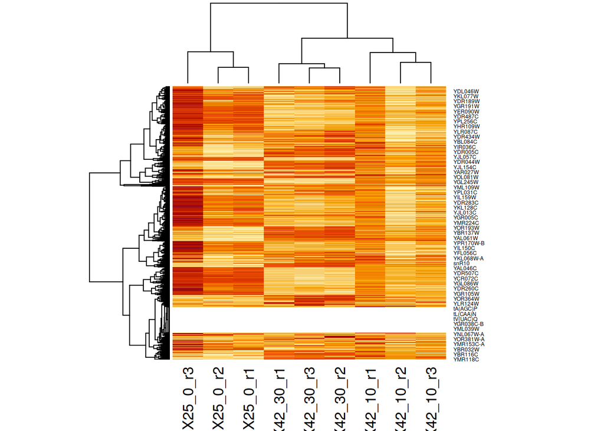

```r
data <- survey
data$gene_id <- NULL
rownames(data) = survey$gene_id
data_matrix <- as.matrix(log(data+1))
heatmap(data_matrix)
```

## Top 50 highest expressed genes based on row sums

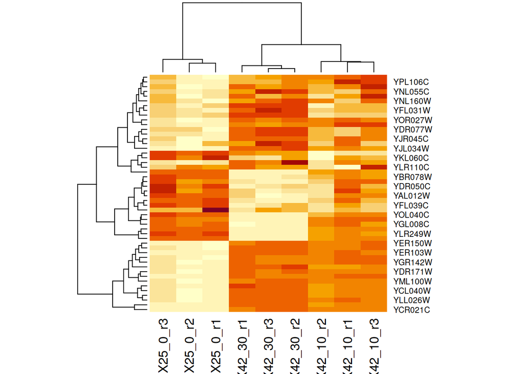

```r
data$sums <- rowSums(data)
top_fifty <- data %>%
         filter(rank(desc(sums))<=50)
top_fifty$sums = NULL
top_fifty = as.matrix(log(top_fifty+1))
heatmap(top_fifty)
```

```r
data$sums = NULL
```

## Top 50 changing genes determined by the maximum absolute difference between the means of 10min and 0min and the means of 30min and 10min.

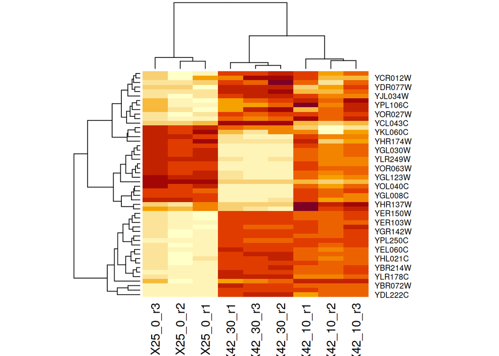

```r
data$dif <- abs(rowMeans(data[1:3]) - rowMeans(data[4:6])) + abs(rowMeans(data[4:6]) - rowMeans(data[7:9]))
top_fifty2 <- data %>%
         filter(rank(desc(dif))<=50)
top_fifty2$dif = NULL
top_fifty2 = as.matrix(log(top_fifty2+1))
heatmap(top_fifty2)
```

```r
data$dif = NULL
```

## Top 50 non-changing genes identified by the minimum absolute difference between the means of 10min and 0min and the means of 30min and 10min. Exclude genes that have not been measured at all.

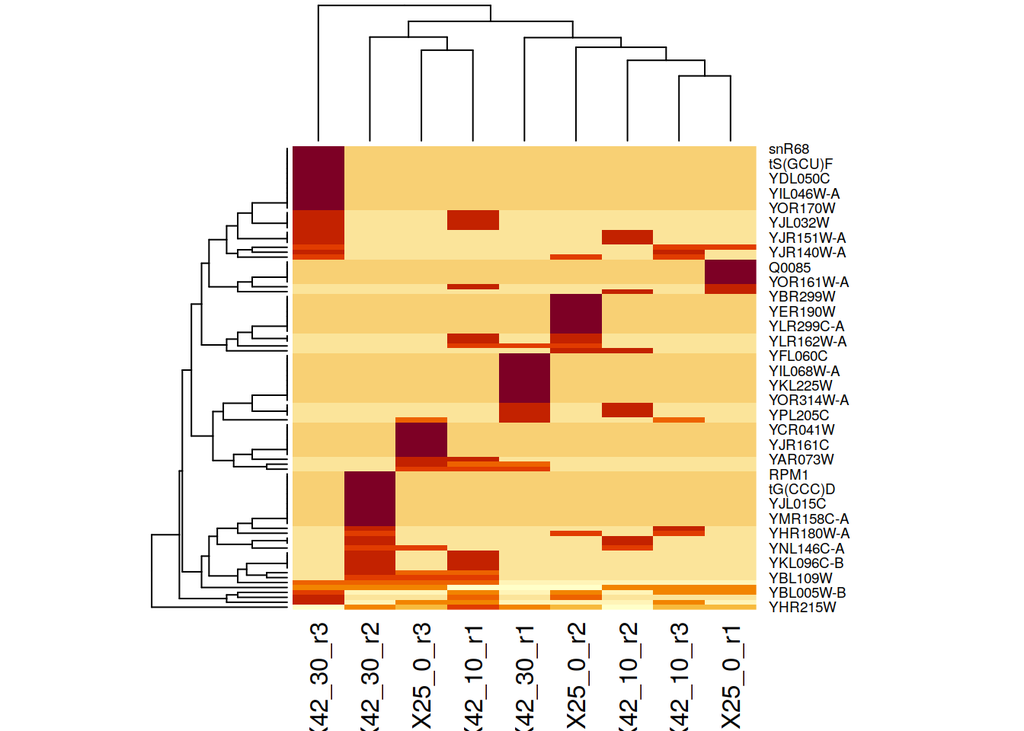

```r
measured <- data[rowSums(data[])>0,]
measured$dif <- abs(rowMeans(measured[1:3]) - rowMeans(measured[4:6])) + abs(rowMeans(measured[4:6]) - rowMeans(measured[7:9]))
top_fifty3 <- measured %>%
         filter(rank(desc(dif))>=6404)
top_fifty3$dif = NULL
top_fifty3 = as.matrix(log(top_fifty3+1))
heatmap(top_fifty3)
```

## Top 50 genes that only show changes at the beginning, determined by the maximum absolute difference between the means of 10min and 0min and the minimum absolute difference between the means of 30min and 10min.

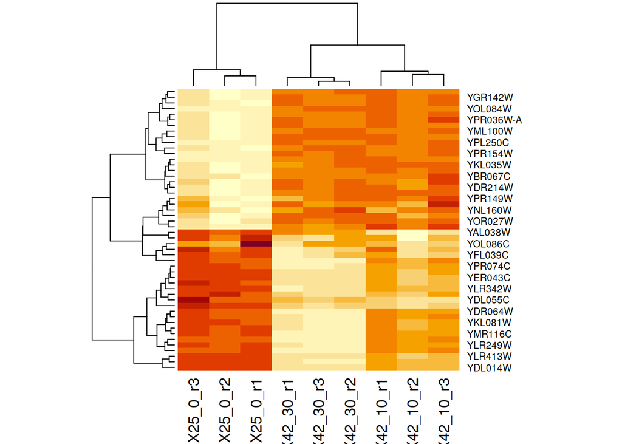

```r
data$dif <- abs(rowMeans(data[1:3]) - rowMeans(data[4:6])) - abs(rowMeans(data[4:6]) - rowMeans(data[7:9]))
top_fifty2 <- data %>%
         filter(rank(desc(dif))<=50)
top_fifty2$dif = NULL
top_fifty2 = as.matrix(log(top_fifty2+1))
heatmap(top_fifty2)
```

```r
data$dif = NULL
```

## Clustering and heatmap using pheatmap

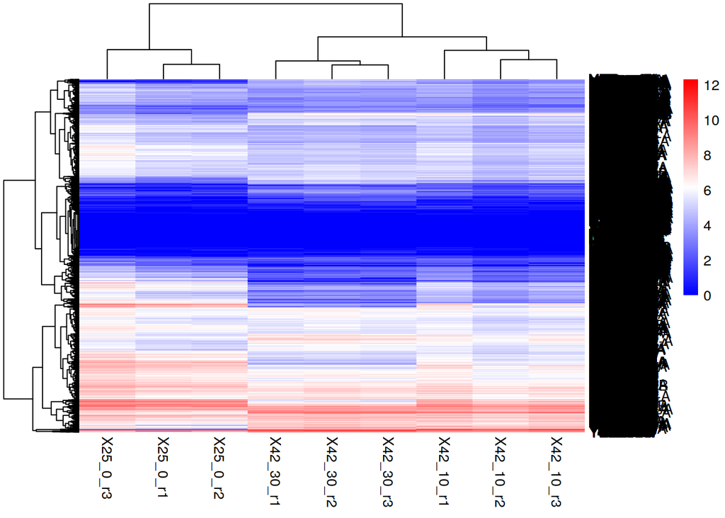

```r
library(pheatmap)
row_clusters <- hclust(dist(data_matrix))
column_clusters <- hclust(dist(t(data_matrix)))
pheatmap(data_matrix,
         clustering_method = "complete",  # Method used for clustering
         cluster_rows = TRUE,  # Perform row clustering
         cluster_cols = TRUE,  # Perform column clustering
         row_cluster_dist = "euclidean",  # Distance metric for row clustering
         col_cluster_dist = "euclidean",  # Distance metric for column clustering
         row_dendrogram = TRUE,  # Display row dendrogram
         col_dendrogram = TRUE,  # Display column dendrogram
         color = colorRampPalette(c("blue", "white", "red"))(100))  # Color palette for heatmap
```